# Affect-AAT PANAS Model

Kristina Kobrock

11 3 2022

# The role of affect in the Automatic Approach Bias: An empirical investigation.

## Mood induction

Load the preprocessed data (see DataAnalysis.Rmd for details).

```r
load("panas.Rdata")
```

### Was the mood induction successful?

1. positive mood induction: panas_score for positive affect higher in panas_2 than in panas_1
2. negative mood induction: panas_score for negative affect higher in panas_2 than in panas_1 –> calculate PA and NA panas_scores for each participant –> compare and check for statistical significance

### Visual inspection:

The data is recoded such that NA scale panas scores receive a negative leading sign.

```
## # A tibble: 8 x 5
## # Groups:   mood_induction, item_affect [4]
##   mood_induction item_affect panas_nr  mean    sd
##   <chr>          <chr>       <chr>    <dbl> <dbl>
## 1 negative       NA          1        -20.8  5.56
## 2 negative       NA          2        -23.6  5.33
## 3 negative       PA          1         21.1  5.13
## 4 negative       PA          2         24.5  5.84
## 5 positive       NA          1        -20.8  4.85
## 6 positive       NA          2        -21.6  4.91
## 7 positive       PA          1         20.5  5.17
## 8 positive       PA          2         22.4  4.83
```

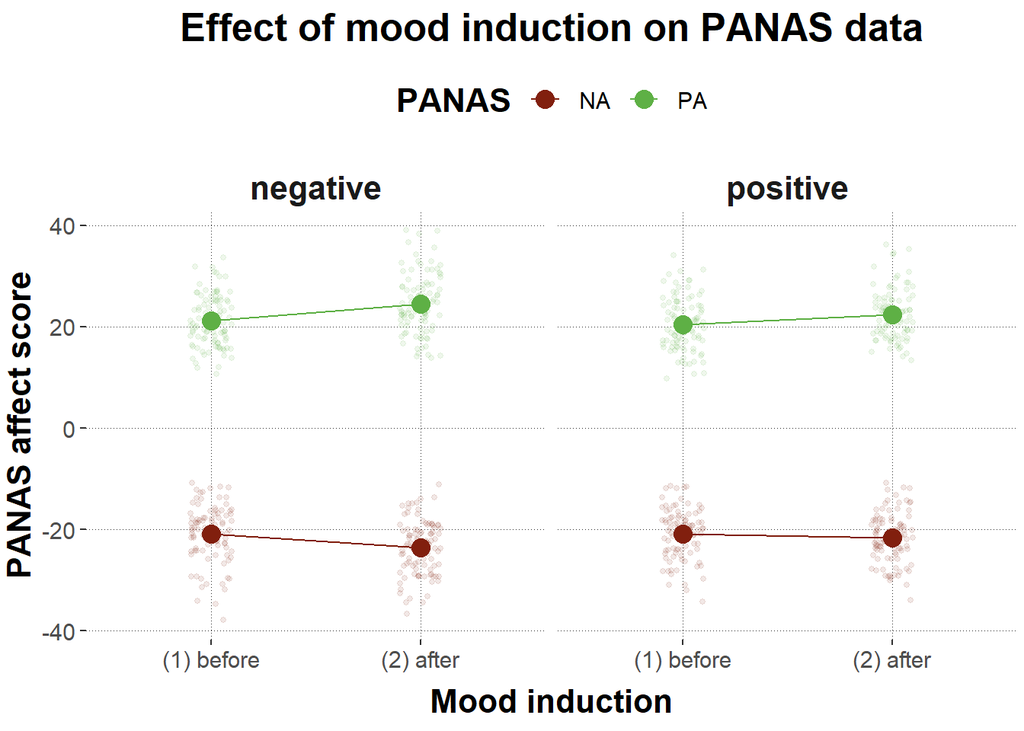

There are some observed differences in means between the groups. Notably, after negative mood induction, not only NA is elevated, but also PA. The differences after positive mood induction do not seem to be as pronounced as after negative mood induction, but here as well both PA and NA seem to be elevated.

### Statistical model

I didn’t specify any model specific priors beforehand but used the default priors instead. For the coefficient priors I decided for priors slightly informed by the data but agnostic to the hypotheses.

```
##  Family: gaussian
##   Links: mu = identity; sigma = identity
## Formula: panas_score ~ item_affect * panas_nr * mood_induction + (item_affect * panas_nr * mood_induction || subject_id)
##    Data: df_affect_mutate (Number of observations: 760)
##   Draws: 4 chains, each with iter = 6000; warmup = 3000; thin = 1;
##          total post-warmup draws = 12000
##
## Priors:
## b ~ normal(0, 10)
## b_item_affectPA ~ normal(44, 5)
## Intercept ~ normal(-22, 5)
## sd ~ student_t(3, 0, 5)
## sigma ~ student_t(3, 0, 31.9)
##
## Group-Level Effects:
## ~subject_id (Number of levels: 95)
##                                                    Estimate Est.Error l-95% CI
## sd(Intercept)                                          2.90      0.34     2.27
## sd(item_affectPA)                                      6.28      0.57     5.24
## sd(panas_nr2)                                          0.33      0.25     0.01
## sd(mood_inductionpositive)                             2.25      0.40     1.48
## sd(item_affectPA:panas_nr2)                            0.61      0.44     0.02
## sd(item_affectPA:mood_inductionpositive)               2.10      0.77     0.38
## sd(panas_nr2:mood_inductionpositive)                   0.36      0.27     0.01
## sd(item_affectPA:panas_nr2:mood_inductionpositive)     0.55      0.41     0.02
##                                                    u-95% CI Rhat Bulk_ESS
## sd(Intercept)                                          3.57 1.00     3556
## sd(item_affectPA)                                      7.48 1.00     3068
## sd(panas_nr2)                                          0.92 1.00     5657
## sd(mood_inductionpositive)                             3.03 1.00     3943
## sd(item_affectPA:panas_nr2)                            1.64 1.00     4216
## sd(item_affectPA:mood_inductionpositive)               3.47 1.00     1845
## sd(panas_nr2:mood_inductionpositive)                   1.01 1.00     6875
## sd(item_affectPA:panas_nr2:mood_inductionpositive)     1.55 1.00     6998
##                                                    Tail_ESS
## sd(Intercept)                                          6935
## sd(item_affectPA)                                      5423
## sd(panas_nr2)                                          5441
## sd(mood_inductionpositive)                             4686
## sd(item_affectPA:panas_nr2)                            5540
```

[output cut: 16 more lines]

```
## item_affectPA                                     43.49 1.00     2779     4810
## panas_nr2                                         -1.76 1.00     6922     9238
## mood_inductionpositive                             1.08 1.00     6668     8310
## item_affectPA:panas_nr2                            7.50 1.00     6591     8851
## item_affectPA:mood_inductionpositive               0.75 1.00     6713     8449
## panas_nr2:mood_inductionpositive                   3.44 1.00     6053     7861
## item_affectPA:panas_nr2:mood_inductionpositive    -1.43 1.00     5874     8147
##
## Family Specific Parameters:
##       Estimate Est.Error l-95% CI u-95% CI Rhat Bulk_ESS Tail_ESS
## sigma     3.51      0.14     3.24     3.80 1.00     2322     5290
##
## Draws were sampled using sampling(NUTS). For each parameter, Bulk_ESS
## and Tail_ESS are effective sample size measures, and Rhat is the potential
## scale reduction factor on split chains (at convergence, Rhat = 1).
```

The model converged with effective samples sizes far above 1.000 and all Rhat values = 1.00. The intercept corresponds to the NA score before a negative mood induction. The effect of item_affectPA is no effect, but rather due to the coding of the panas_score variable I chose where PA scores have a positive leading sign and NA scores a negative leading sign. So this can be read as a second intercept (which is calculated by adding it to the model intercept) that corresponds to the PA score before a negative mood induction. There is an effect for panas_nr2 that can be read directly from the population-level effects. It means that after negative mood induction, the NA score is elevated (i.e. more negative) by an amount of about 2.75. Another effect seems to lie in the three-way interaction. But in order to interpret it, the individual posteriors have to be grouped and summed up. Posterior predictive checks also show that the model converged nicely to the bimodal distribution of PANAS score:

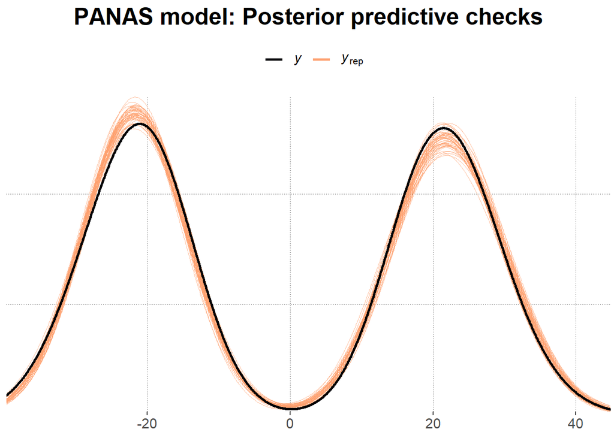

Calculating the difference distributions of both PA and NA scores before and after the respective mood inductions.

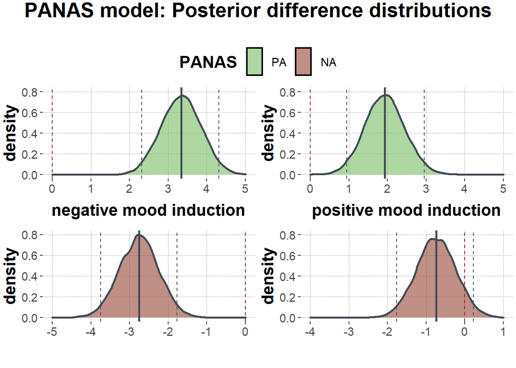

All differences seem to be substantial except for NA in the positive mood induction condition. Here are summaries of the medians, 95% credible intervals, probability of direction and ROPE test: ROPE stands for “Region of practical equivalence” and defines a region that can be assumed to be equivalent to zero for a given dataset (one common practice is to calculate the rope range using the tenth of the standard deviation of the response variable according to Cohen, 1988). The result of a ROPE test can be interpreted as follows:

```
> 99% in ROPE: negligible (we can accept the null hypothesis)
> 97.5% in ROPE: probably negligible
<= 97.5% & >= 2.5% in ROPE: undecided significance
< 2.5% in ROPE: probably significant
< 1% in ROPE: significant (we can reject the null hypothesis)
```

The probability of direction is strongly correlated with the p-value from frequentist statistics:

```
pd <= 95% ~ p > .1: uncertain
pd > 95% ~ p < .1: possibly existing
pd > 97.5% ~ p < .05: likely existing
pd > 99.5% ~ p < .01 probably existing
pd > 99.9% ~ p< .001 certainly existing
```

```
## [1] "PA difference for negative mood induction:"
```

```
## Summary of Posterior Distribution
##
## Parameter | Median |       95% CI |   pd |          ROPE | % in ROPE
## --------------------------------------------------------------------
## posterior |   3.34 | [2.32, 4.31] | 100% | [-2.26, 2.26] |        0%
```

```
## [1] "NA difference for negative mood induction:"
```

```
## Summary of Posterior Distribution
##
## Parameter | Median |         95% CI |   pd |          ROPE | % in ROPE
## ----------------------------------------------------------------------
## posterior |  -2.75 | [-3.75, -1.76] | 100% | [-2.26, 2.26] |    14.75%
```

```
## [1] "PA difference for positive mood induction:"
```

```
## Summary of Posterior Distribution
##
## Parameter | Median |       95% CI |     pd |          ROPE | % in ROPE
## ----------------------------------------------------------------------
## posterior |   1.93 | [0.94, 2.96] | 99.98% | [-2.26, 2.26] |    75.34%
```

```
## [1] "NA difference for positive mood induction:"
```

```
## Summary of Posterior Distribution
##
## Parameter | Median |        95% CI |     pd |          ROPE | % in ROPE
## -----------------------------------------------------------------------
## posterior |  -0.74 | [-1.77, 0.23] | 92.59% | [-2.26, 2.26] |      100%
```

Let’s first consider the difference in panas score when after compared to before a negative mood induction: Other than I would have expected, the difference in PA score before compared to after the negative mood induction is substantial. The effect has a probability of 100% of being positive (i.e. PA is elevated) (median = 3.34, 95% CrI [2.32, 4.31] and can be considered as significant (0% in ROPE). The difference in NA score is also substantial. The effect has a probability of 100% of being negative (i.e. NA is elevated) (median = -2.75, 95% CrI [-3.75, -1.76]). With a quite wide ROPE range informed by the posterior distribution (one tenth of the standard deviation which can be assumed to be negligible accordig to Cohen, 1988), the effect would not be significant (14.75% in ROPE). But according to the probability of direction, there is high certainty for the effect, so I’m assuming that it is, in fact, present and I just chose a quite strict ROPE range.

Next, let’s have a look at positive mood induction: Positive mood induction did not have such strong effects as negative mood induction. Here, again, we find quite some evidence for a difference in PA score (median = 1.93, 95% CrI [0.94, 2.96]). The probability of the effect being positive (i.e. PA is elevated) is 99.98%. Again, according to the ROPE interval I chose, the effect cannot be regarded as significant, but I will still assume that there is enough evidence for the effect. NA difference is not substantial as already suggested by the posterior difference plots. The effect has a probability of 92.59% of being negative (median = -0.74, 95% CrI [-1.77, 0.23]) and is not significant (100% in ROPE).

```
## # A tibble: 8 x 7
## # Groups:   parameter, mood_induction, panas_nr [8]
##   parameter      mood_induction panas_nr   PANAS pred_m pred_low pred_high
##   <chr>          <chr>          <chr>      <chr>  <dbl>    <dbl>     <dbl>
## 1 NAafterNegind  negative       (2) after  NA     -23.7    -24.6     -22.8
## 2 NAafterPosind  positive       (2) after  NA     -21.7    -22.7     -20.6
## 3 NAbeforeNegind negative       (1) before NA     -20.9    -21.9     -20.1
## 4 NAbeforePosind positive       (1) before NA     -21.0    -22.0     -20.0
## 5 PAafterNegind  negative       (2) after  PA      24.3     22.6      25.7
## 6 PAafterPosind  positive       (2) after  PA      22.1     20.4      23.8
## 7 PAbeforeNegind negative       (1) before PA      20.9     19.3      22.4
## 8 PAbeforePosind positive       (1) before PA      20.2     18.6      21.9
```

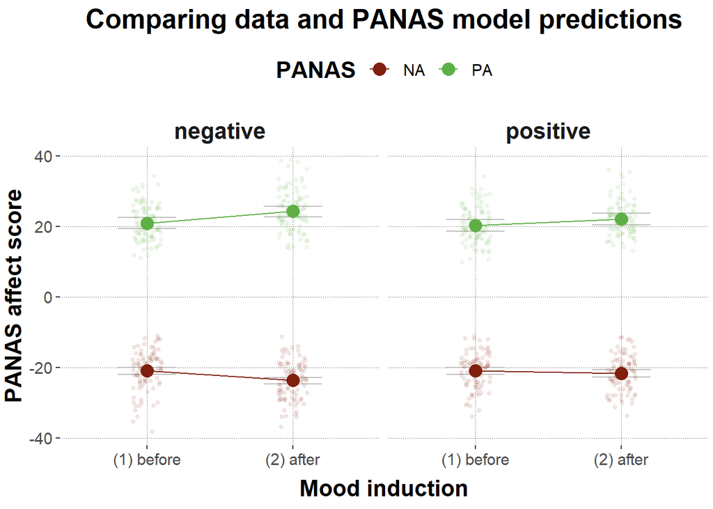